# Lab 1 - Аналитика и визуализация данных в R

by: eagbozo

## Measles Dataset

The data this week comes from The Wallstreet Journal. They recently published an article around 46,412 schools across 32 US States.

“This repository contains immunization rate data for schools across the U.S., as compiled by The Wall Street Journal. The dataset includes the overall and MMR-specific vaccination rates for 46,412 schools in 32 states. As used in “What’s the Measles Vaccination Rate at Your Child’s School?“.

Vaccination rates are for the 2017-18 school year for Colorado, Connecticut, Minnesota, Montana, New Jersey, New York, North Dakota, Pennsylvania, South Dakota, Utah and Washington. Rates for other states are 2018-19."

### Loading the Dataset and Obtaining Quick Summaries of Observations

1. First we load the dataset remotely
2. Next, we summarize the dataset for basic statistical summaries
3. We also explore the first and last few observations

```r
measles <- readr::read_csv('https://raw.githubusercontent.com/rfordatascience/tidytuesday/master/data/2020/2020-02-25/measles.csv')
summary(measles)
```

```
##      index         state               year               name
##  Min.   :   1   Length:66113       Length:66113       Length:66113
##  1st Qu.: 429   Class :character   Class :character   Class :character
##  Median : 997   Mode  :character   Mode  :character   Mode  :character
##  Mean   :1608
##  3rd Qu.:2133
##  Max.   :8066
##
##      type               city              county          district
##  Length:66113       Length:66113       Length:66113       Mode:logical
##  Class :character   Class :character   Class :character   NA's:66113
##  Mode  :character   Mode  :character   Mode  :character
##
##
##
##
##      enroll            mmr            overall         xrel
##  Min.   :   0.0   Min.   : -1.00   Min.   : -1.00   Mode:logical
##  1st Qu.:  46.0   1st Qu.: -1.00   1st Qu.: -1.00   TRUE:109
##  Median :  80.0   Median : 95.00   Median : 87.00   NA's:66004
##  Mean   : 131.9   Mean   : 63.17   Mean   : 54.09
##  3rd Qu.: 129.0   3rd Qu.: 98.00   3rd Qu.: 96.10
##  Max.   :6222.0   Max.   :100.00   Max.   :100.00
##  NA's   :16260
##       xmed             xper             lat             lng
##  Min.   :  0.04   Min.   :  0.17   Min.   :24.55   Min.   :-124.50
##  1st Qu.:  1.00   1st Qu.:  2.84   1st Qu.:35.69   1st Qu.:-117.63
##  Median :  2.00   Median :  5.00   Median :40.21   Median : -89.97
##  Mean   :  2.91   Mean   :  6.78   Mean   :39.15   Mean   : -96.28
##  3rd Qu.:  3.53   3rd Qu.:  7.55   3rd Qu.:42.18   3rd Qu.: -81.75
##  Max.   :100.00   Max.   :169.23   Max.   :49.00   Max.   :  80.21
##  NA's   :45122    NA's   :57560    NA's   :1549    NA's   :1549
```

```r
#Get first few observations
head(measles)
```

```
## # A tibble: 6 x 16
##   index state year  name  type  city  county district enroll   mmr overall xrel
##   <dbl> <chr> <chr> <chr> <chr> <chr> <chr>  <lgl>     <dbl> <dbl>   <dbl> <lgl>
## 1     1 Ariz~ 2018~ A J ~ Publ~ Noga~ Santa~ NA           51   100      -1 NA
## 2     2 Ariz~ 2018~ Acad~ Char~ Tucs~ Pima   NA           22   100      -1 NA
## 3     3 Ariz~ 2018~ Acad~ Char~ Tucs~ Pima   NA           85   100      -1 NA
## 4     4 Ariz~ 2018~ Acad~ Char~ Phoe~ Maric~ NA           60   100      -1 NA
## 5     5 Ariz~ 2018~ Accl~ Char~ Phoe~ Maric~ NA           43   100      -1 NA
## 6     6 Ariz~ 2018~ Alfr~ Publ~ Phoe~ Maric~ NA           36   100      -1 NA
## # ... with 4 more variables: xmed <dbl>, xper <dbl>, lat <dbl>, lng <dbl>
```

```r
#Get last few observations
tail(measles)
```

```
## # A tibble: 6 x 16
##   index state year  name  type  city  county district enroll   mmr overall xrel
##   <dbl> <chr> <chr> <chr> <chr> <chr> <chr>  <lgl>     <dbl> <dbl>   <dbl> <lgl>
## 1  1511 Wisc~ 2018~ Vanc~ <NA>  Prai~ Barron NA           NA    -1      -1 NA
## 2  1512 Wisc~ 2018~ Waln~ <NA>  Hill~ Sauk   NA           NA    -1      -1 NA
## 3  1513 Wisc~ 2018~ Wauw~ <NA>  Wauw~ Milwa~ NA           NA    -1      -1 NA
## 4  1514 Wisc~ 2018~ West~ <NA>  West~ Marat~ NA           NA    -1      -1 NA
## 5  1514 Wisc~ 2018~ West~ <NA>  West~ Marat~ NA           NA    -1      -1 NA
## 6  1515 Wisc~ 2018~ WISE~ <NA>  Neko~ Wood   NA           NA    -1      -1 NA
## # ... with 4 more variables: xmed <dbl>, xper <dbl>, lat <dbl>, lng <dbl>
```

Observations appear as *tibbles*. A tibble, or tbl_df, is a modern reimagining of the data.frame, keeping what time has proven to be effective, and throwing out what is not (https://tibble.tidyverse.org/).

The summary function provides us with a brief statistical description of each feature in our dataset. Depending on the nature of the feature in consideration, different statistics will be provided:

```r
#get total number of columns in dataset
ncol(measles)
```

```
## [1] 16
```

```r
#get total number of rows/observations
nrow(measles)
```

```
## [1] 66113
```

```r
#get total number of observations for measles and mumps vaccination rate [A PARTICULAR COLUMN]
length(measles$mmr)
```

```
## [1] 66113
```

### Data Exploration

Before performing any form of statistical analysis, it is important we explore the dataset. Standard checks for **NA** *(Not Available)* or empty observations / **missing values** will be performed.

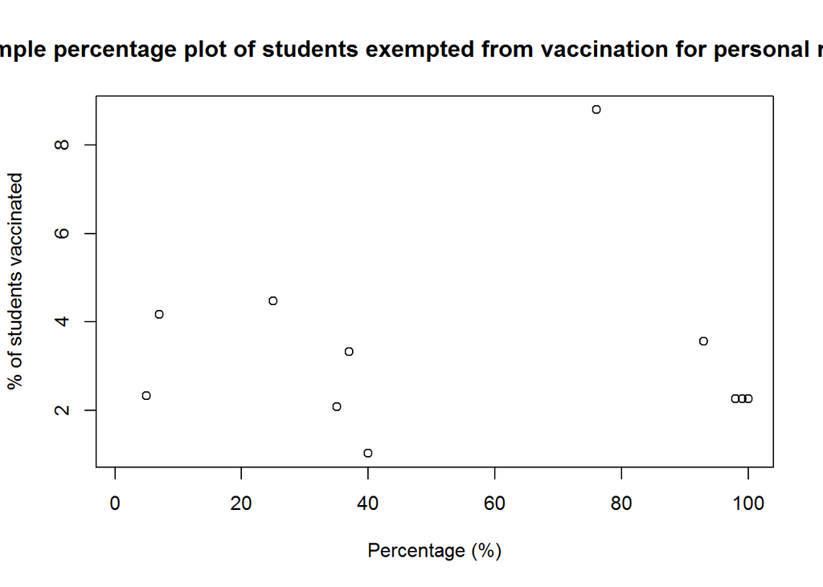

```r
#PLOT FIRST 100 OBSERVATIONS OF THE Percentage of students exempted from vaccination for personal reasons
plot(measles$xper[1:100], main = "Sample percentage plot of students exempted from vaccination for personal reasons", ylab = "% of students vaccinated" , xlab = "Percentage (%)")
```

We observe a **HIGH LEVEL OF sparsity** in our data plot. Out of 100 observations we can count **only 11 readings** Let’s verify

```r
# Checking for Missing values

#Explore number of vaccination exemptions from the 220th to the 430th observation
measles$xmed[220:430]
```

```
##   [1]   NA   NA   NA   NA   NA   NA   NA   NA   NA   NA   NA   NA   NA   NA   NA
##  [16]   NA   NA 1.64 1.64 1.64 1.64   NA   NA   NA   NA   NA   NA   NA   NA   NA
##  [31]   NA   NA   NA   NA   NA   NA   NA   NA   NA   NA   NA   NA   NA   NA   NA
##  [46]   NA   NA 3.85   NA   NA 0.98 5.88   NA   NA   NA   NA   NA   NA   NA   NA
##  [61] 2.04   NA   NA   NA   NA   NA   NA   NA   NA   NA 2.08 0.70   NA   NA   NA
##  [76]   NA   NA   NA   NA   NA   NA   NA   NA   NA   NA   NA   NA   NA   NA   NA
##  [91]   NA   NA   NA   NA   NA   NA   NA   NA   NA 0.81   NA   NA   NA   NA   NA
## [106]   NA   NA   NA 1.27   NA   NA   NA   NA   NA   NA   NA 1.30 1.30 2.63   NA
## [121]   NA   NA   NA   NA   NA 1.33   NA   NA   NA 0.90   NA   NA   NA   NA   NA
## [136]   NA   NA 2.78   NA   NA   NA   NA   NA   NA   NA   NA   NA   NA   NA   NA
## [151]   NA   NA   NA   NA   NA   NA   NA   NA   NA   NA 1.49   NA   NA   NA   NA
## [166]   NA   NA 1.52   NA   NA   NA   NA   NA   NA   NA   NA   NA   NA   NA   NA
## [181]   NA   NA 1.60   NA   NA   NA   NA   NA   NA 1.09   NA   NA   NA   NA   NA
## [196] 3.33   NA   NA   NA   NA   NA 3.33   NA   NA 3.33   NA   NA 1.68 1.12   NA
## [211] 1.69
```

```r
#we notice there are NAs

na.omit(measles$xmed[220:430])
```

```
##  [1] 1.64 1.64 1.64 1.64 3.85 0.98 5.88 2.04 2.08 0.70 0.81 1.27 1.30 1.30 2.63
## [16] 1.33 0.90 2.78 1.49 1.52 1.60 1.09 3.33 3.33 3.33 1.68 1.12 1.69
## attr(,"na.action")
##   [1]   1   2   3   4   5   6   7   8   9  10  11  12  13  14  15  16  17  22
##  [19]  23  24  25  26  27  28  29  30  31  32  33  34  35  36  37  38  39  40
##  [37]  41  42  43  44  45  46  47  49  50  53  54  55  56  57  58  59  60  62
##  [55]  63  64  65  66  67  68  69  70  73  74  75  76  77  78  79  80  81  82
##  [73]  83  84  85  86  87  88  89  90  91  92  93  94  95  96  97  98  99 101
##  [91] 102 103 104 105 106 107 108 110 111 112 113 114 115 116 120 121 122 123
## [109] 124 125 127 128 129 131 132 133 134 135 136 137 139 140 141 142 143 144
## [127] 145 146 147 148 149 150 151 152 153 154 155 156 157 158 159 160 162 163
## [145] 164 165 166 167 169 170 171 172 173 174 175 176 177 178 179 180 181 182
## [163] 184 185 186 187 188 189 191 192 193 194 195 197 198 199 200 201 203 204
## [181] 206 207 210
## attr(,"class")
## [1] "omit"
```

```r
#we notice there are now no NAs

#let's count the number of vaccination exemptions from the 220th to the 430th observation WITH NO NAs
length(na.omit(measles$xmed[220:430]))
```

```
## [1] 28
```

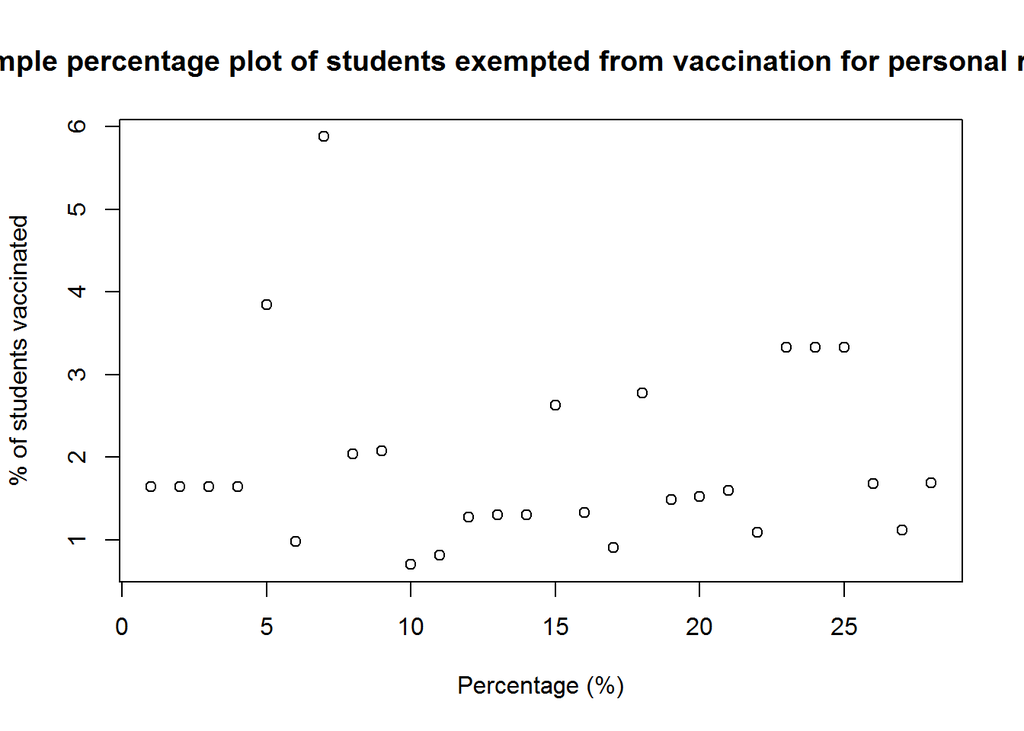

```r
#PLOT SAMPLE OBSERVATIONS OF THE Percentage of students exempted from vaccination for personal reasons
plot(na.omit(measles$xmed[220:430]), main = "Sample percentage plot of students exempted from vaccination for personal reasons", ylab = "% of students vaccinated" , xlab = "Percentage (%)")
```

##### Subsetting

```r
#Select all observations of students exempted for medical reasons from Arizona
measles$xmed[measles$state =="Arizona"]
```

```
##    [1]   NA   NA   NA   NA 2.33   NA   NA   NA   NA   NA   NA 2.86   NA 7.41
##   [15]   NA   NA   NA 2.13   NA   NA   NA   NA   NA   NA   NA   NA   NA   NA
##   [29]   NA   NA   NA   NA   NA   NA   NA   NA   NA   NA   NA   NA   NA   NA
##   [43]   NA   NA   NA   NA   NA   NA   NA   NA   NA   NA   NA   NA   NA   NA
##   [57] 2.08   NA   NA   NA 1.27   NA   NA 0.93   NA 2.63   NA   NA   NA   NA
##   [71]   NA   NA   NA   NA   NA   NA   NA   NA   NA   NA   NA   NA   NA 9.52
##   [85]   NA 1.52   NA   NA   NA   NA   NA   NA   NA   NA   NA   NA   NA 4.55
##   [99] 4.55 4.55   NA   NA 3.03   NA   NA   NA   NA   NA   NA   NA   NA   NA
##  [113]   NA   NA 1.47   NA   NA   NA   NA   NA   NA   NA   NA   NA   NA   NA
##  [127]   NA   NA   NA   NA   NA   NA   NA   NA   NA   NA   NA   NA   NA   NA
##  [141]   NA   NA   NA   NA   NA   NA   NA   NA   NA   NA   NA   NA   NA   NA
##  [155]   NA   NA   NA   NA   NA   NA   NA 1.72   NA   NA   NA   NA   NA   NA
##  [169]   NA   NA   NA   NA   NA 0.93   NA   NA   NA   NA   NA   NA   NA   NA
##  [183] 1.16   NA   NA   NA   NA   NA 1.19   NA 1.20   NA   NA   NA   NA   NA
##  [197]   NA   NA   NA   NA   NA 1.30   NA   NA   NA   NA   NA   NA   NA   NA
```

[output cut: 89 more lines]

```r
#show less sparse observations from the previous statement
na.omit(measles$xmed[measles$state =="Arizona"])
```

```
##   [1] 2.33 2.86 7.41 2.13 2.08 1.27 0.93 2.63 9.52 1.52 4.55 4.55 4.55 3.03 1.47
##  [16] 1.72 0.93 1.16 1.19 1.20 1.30 1.37 1.64 1.64 1.64 1.64 3.85 0.98 5.88 2.04
##  [31] 2.08 0.70 0.81 1.27 1.30 1.30 2.63 1.33 0.90 2.78 1.49 1.52 1.60 1.09 3.33
##  [46] 3.33 3.33 1.68 1.12 1.69 1.75 1.18 0.90 3.64 0.62 3.85 3.90 4.00 4.00 1.33
##  [61] 1.35 1.41 1.43 2.86 4.35 1.45 2.90 2.90 2.90 2.90 2.20 1.49 1.49 1.49 2.33
##  [76] 4.76 2.38 1.61 1.25 2.50 1.01 1.32 1.32 1.75 1.33 1.10 0.93 1.15 1.16 1.16
##  [91] 0.85 1.38 2.00 1.25 2.11 0.91 0.91 1.28 0.93 3.28 0.83 1.33 1.94 3.51 3.57
## [106] 0.72 0.72 1.85 1.08 0.76 1.27 1.27 1.09 2.63 2.00 0.90 3.28 1.64 0.83 0.70
## [121] 1.43 6.67 2.00 5.19 0.62 0.85 1.35 1.10 1.11 0.92 0.93 2.11 1.33 5.56 1.92
## [136] 1.92 1.92 1.19 2.70 1.05 1.64 0.95 1.22 1.23 1.71 1.49 1.49 1.22 1.03 3.57
## [151] 1.27 2.38 5.13 3.03 2.22 1.41 1.61 0.87 1.89 2.56 2.56 2.56
## attr(,"na.action")
##    [1]    1    2    3    4    6    7    8    9   10   11   13   15   16   17
##   [15]   19   20   21   22   23   24   25   26   27   28   29   30   31   32
##   [29]   33   34   35   36   37   38   39   40   41   42   43   44   45   46
```

[output cut: 92 more lines]

what do you observe between these two plots

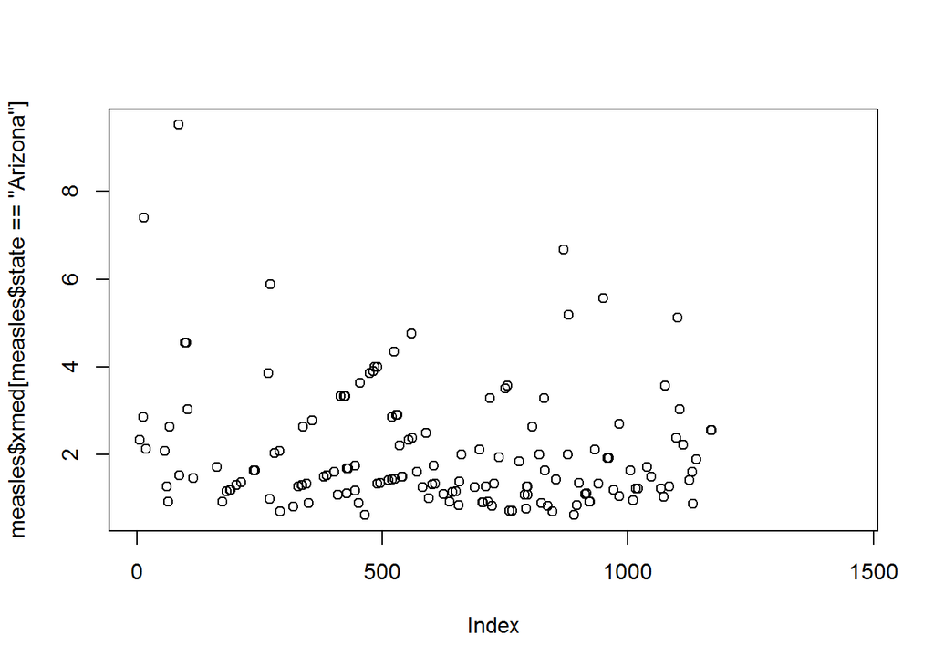

```r
plot(measles$xmed[measles$state =="Arizona"])
```

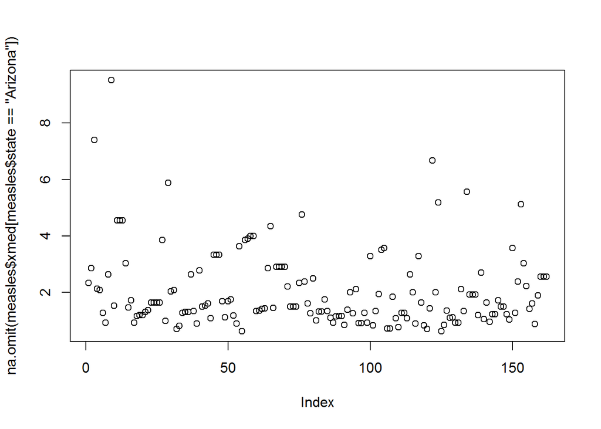

```r
plot(na.omit(measles$xmed[measles$state =="Arizona"]))
```

##### Get all unique states (with the **dplyr** library)

```r
library(dplyr)
unique(measles$state)
```

```
##  [1] "Arizona"        "Arkansas"       "California"     "Colorado"
##  [5] "Connecticut"    "Florida"        "Idaho"          "Illinois"
##  [9] "Iowa"           "Maine"          "Massachusetts"  "Michigan"
## [13] "Minnesota"      "Missouri"       "Montana"        "New Jersey"
## [17] "New York"       "North Carolina" "North Dakota"   "Oklahoma"
## [21] "Ohio"           "Oregon"         "Pennsylvania"   "Rhode Island"
## [25] "South Dakota"   "Tennessee"      "Texas"          "Utah"
## [29] "Vermont"        "Virginia"       "Washington"     "Wisconsin"
```

3-D Scatterplots

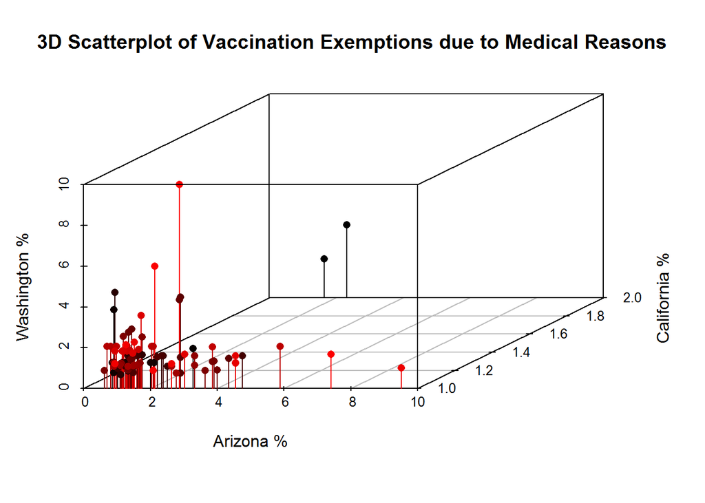

```r
library(scatterplot3d)

#select only 100 observations of medical exemption reason data for 3 states
ar <- na.omit(measles$xmed[measles$state =="Arizona"])[1:100]
ca <- na.omit(measles$xmed[measles$state =="California"])[1:100]
wa <- na.omit(measles$xmed[measles$state =="Washington"])[1:100]

#we selected 100 so that plotting will be easier
scatterplot3d(ar,ca,wa, pch=16, highlight.3d=TRUE,
  type="h", main="3D Scatterplot of Vaccination Exemptions due to Medical Reasons",
  xlab = "Arizona %", ylab = "California %", zlab = "Washington %" )
```

##### Box Plots

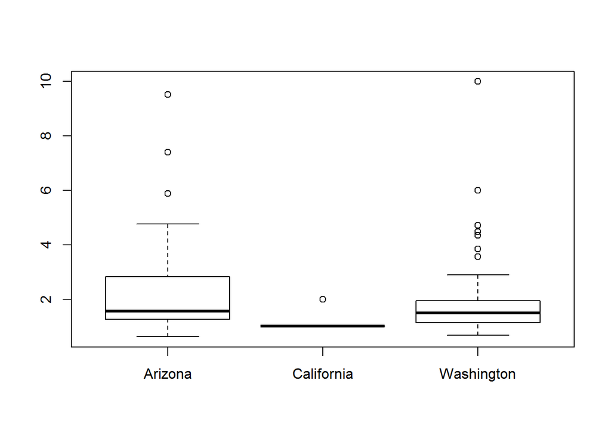

```r
boxplot(ar,ca,wa, names = c("Arizona","California","Washington"))
```

## Dealing with missing data

#### Data Imputation Techniques

Methods can be: * Deletion * Mean/ Mode/ Median Imputation * Prediction Model *(sophisticated method)* * KNN Imputation

Let’s first view the pattern of missing data in our dataset.

**MICE (Multivariate Imputation via Chained Equations)** is one of the commonly used package by R users. Creating multiple imputations as compared to a single imputation (such as mean) takes care of uncertainty in missing values. MICE assumes that the missing data are Missing at Random

It uses: - PMM (Predictive Mean Matching) — For numeric variables - logreg(Logistic Regression) — For Binary Variables( with 2 levels) - polyreg(Bayesian polytomous regression) — For Factor Variables (>= 2 levels) - Proportional odds model (ordered, >= 2 levels)

```r
set.seed(1)

library(mice)
library(VIM)
```

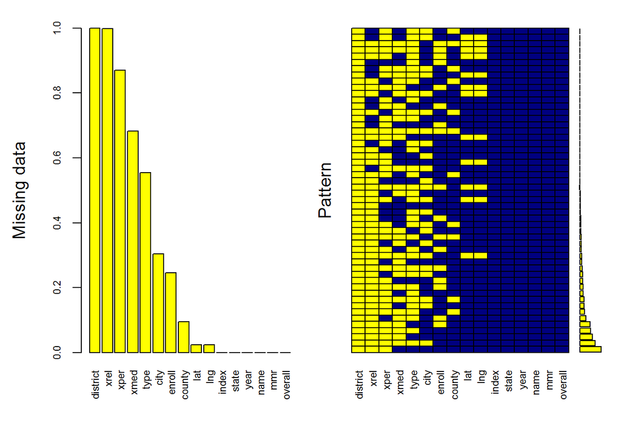

```
##
##  Variables sorted by number of missings:
##  Variable      Count
##  district 1.00000000
##      xrel 0.99835131
##      xper 0.87063059
##      xmed 0.68249815
##      type 0.55393039
##      city 0.30358628
##    enroll 0.24594255
##    county 0.09459562
##       lat 0.02342958
##       lng 0.02342958
##     index 0.00000000
##     state 0.00000000
##      year 0.00000000
##      name 0.00000000
##       mmr 0.00000000
##   overall 0.00000000
```

```r
mice_plot <- aggr(measles, col=c('navyblue','yellow'),
                  numbers=TRUE, sortVars=TRUE,
                  labels=names(measles), cex.axis=.7,
                  gap=3, ylab=c("Missing data","Pattern"))
```

100% missing data in the district column and religious reason column (*xrel*) Above 80% for personal reasons (*xper*) Above 60% for medical reasons (*xmed*)

**Question: Can you describe the percentage of missing data in the other variables (columns)?**

Now, let’s create a new dataset without the **district** and **xrel** variables.

```r
names(measles)
```

```
##  [1] "index"    "state"    "year"     "name"     "type"     "city"
##  [7] "county"   "district" "enroll"   "mmr"      "overall"  "xrel"
## [13] "xmed"     "xper"     "lat"      "lng"
```

```r
measles_clean = measles[c(-8,-12)]

names(measles_clean)
```

```
##  [1] "index"   "state"   "year"    "name"    "type"    "city"    "county"
##  [8] "enroll"  "mmr"     "overall" "xmed"    "xper"    "lat"     "lng"
```

```r
imputed_Data <- mice(measles_clean, m=1, maxit = 1, method = 'pmm', seed = 500)
completeData <- complete(imputed_Data,2)
```

Let’s write our new dataset to a csv

```r
write.csv(file="complete_measlesDF.csv",completeData,fileEncoding = "utf-8")
```

#### Extra

Subsetting based on certain conditions

```r
#let's get all data of Arizona where the reason for exaemption was medical
#az_1.5 = subset(completeData, xmed > 1.5 & state =="Arizona")

#in order to plot the school distribution, we need to create a table (matrix of our variable/column)
#arizona_schs = table(az_1.5$type)
#barplot(arizona_schs)

#x= data.frame(completeData$state,completeData$mmr)

#par(las=2) # make label text perpendicular to axis
#barplot(table(x$completeData.state), horiz=TRUE, cex.names=0.8)
```

#### Tasks

1. What is the average percentage (%) of students who were exempted from vaccination for personal reasons?
2. What is the average percentage (%) of students who were exempted from vaccination for medical reasons?
3. What is the average percentage (%) of students who were exempted from vaccination for religious reasons?
4. Plot a **3D scatterplot** and a **Boxplot** for ONLY 50 observations for *New York, Oregon and Connecticut*
5. Plot a barplot of the distribution of vaccinations (overall) for California